# Final Strategy for Group 1 (NQ & SP) On OUT OF SAMPLE DATA

Anindita Basu, Sana Ahmad

2025-01-26

### Introduction

This report presents our final strategy for Group 1 assets – specifically the NQ (NASDAQ futures) and SP (S&P 500 futures) – utilizing out-of-sample intraday data spanning multiple quarters. We employed a Volatility Breakout Momentum approach, with parameters determined through an extensive in-sample analysis. The report includes: - Detailed strategy assumptions, entry/exit techniques, and parameter values. - Out-of-sample performance metrics across 5 quarters (2022_Q2, 2023_Q1, 2023_Q3, 2024_Q3, 2024_Q4). - Tables of Sharpe ratios, Calmar ratios, net/gross PnL, average daily trades, and final summary statistics. - Cumulative PnL plots based on daily aggregated data for each quarter.

### Final Strategy Selection

#### Volatility Breakout Momentum: Overview

Our final strategy is a Volatility Breakout Momentum approach, characterized by the following steps: 1. **Exponential Moving Averages (EMAs):** - Compute a fast EMA (fastEMA) and a slow EMA (slowEMA) on the price series. 2. **Rolling Volatility Measure:** - Calculate a rolling standard deviation (runsd) over a specified window (vol_sd). 3. **Signal Generation:** - **Long Entry:** When the price exceeds (slowEMA + m_ * rolling_std). - **Short Entry:** When the price falls below (slowEMA - m_ * rolling_std). 4. **Position Flattening:** - **Post-Processing:** After generating raw positions, enforce position flattening outside the active trading window (09:55–15:40) by setting positions to 0.

### Parameter Search

We explored the following parameter ranges to identify the optimal combination: - fast_ema: 10, 20, 30 - slow_ema: 60, 75, 90 - vol_sd: 30, 60, 90 - m_: 1.0, 1.5, 2.0

The parameter set that maximized stat was selected for both NQ and SP: - **NQ:** fastEMA=20, slowEMA=60, vol_sd=60, m_=2 - **SP:** fastEMA=30, slowEMA=60, vol_sd=60, m_=2

These parameters were then held fixed and applied uniformly to all out-of-sample quarters.

### Common Assumptions (Group 1)

- **Time Filtering:**
  - **Excluded Times:**
    - **Morning:** 09:31–09:40
    - **Afternoon:** 15:51–16:00
  - These periods are set to NA to exclude from calculations.
  - **Active Trading Window:** 09:55–15:40
- **Transaction Costs:**
  - $12 per contract change.
- **Position Sizing:**
  - One Unit: Long or short for each NQ and SP.
- **PnL Calculation:**
  - **Combined Daily PnL:** Sum of daily PnL from NQ and SP.

### Results for Group 1 (NQ & SP)

We applied the selected parameters to the in-sample quarters (“2022_Q1”, “2022_Q3”, “2022_Q4”, “2023_Q2”, “2023_Q4”, “2024_Q1”, “2024_Q2”). The table below summarizes those results:

Performance Metrics by Quarter for IN SAMPLE DATA

| quarter | grossSR | netSR | grossCR | netCR | grossPnL | netPnL | av_ntrades | stat |
| --- | --- | --- | --- | --- | --- | --- | --- | --- |
| 2022_Q1 | 0.7350 | 0.6270 | 1.4077 | 1.1758 | 18611.68 | 15875.68 | 3.5625 | 3.2509 |
| 2022_Q3 | 1.7020 | 1.5315 | 3.3628 | 2.9702 | 32023.49 | 28807.49 | 4.0606 | 9.9818 |
| 2022_Q4 | 1.2371 | 1.0169 | 2.8458 | 2.2576 | 18592.13 | 15280.13 | 4.2462 | 6.1553 |
| 2023_Q2 | 0.9625 | 0.5265 | 2.7238 | 1.3503 | 13382.04 | 7358.04 | 7.8438 | 2.6949 |
| 2023_Q4 | 1.0858 | 0.8187 | 3.8468 | 2.7447 | 9067.37 | 6835.37 | 2.9062 | 5.2756 |
| 2024_Q1 | 1.1469 | 0.8646 | 2.8851 | 2.1153 | 12299.19 | 9275.19 | 3.9375 | 4.7114 |
| 2024_Q2 | 3.5069 | 3.2229 | 14.1386 | 12.4749 | 38122.20 | 35026.20 | 3.9692 | 44.3618 |

#### Out-of-Sample Performance (5 Quarters)

We applied the selected parameters to the out-of-sample quarters (2022_Q2, 2023_Q1, 2023_Q3, 2024_Q3, 2024_Q4). The table below summarizes those results:

Performance Metrics by Quarter for OUT OF SAMPLE DATA

| quarter | grossSR | netSR | grossCR | netCR | grossPnL | netPnL | av_ntrades | stat |
| --- | --- | --- | --- | --- | --- | --- | --- | --- |
| 2022_Q2 | 0.4556 | 0.3288 | 1.0755 | 0.7475 | 11201.14 | 8081.14 | 4.0000 | 1.5619 |
| 2023_Q1 | 1.4905 | 1.2288 | 2.2542 | 1.8207 | 23518.84 | 19390.84 | 5.2923 | 5.3981 |
| 2023_Q3 | 0.6114 | 0.1316 | 0.9607 | 0.1957 | 4988.54 | 1076.54 | 5.0154 | 0.0144 |
| 2024_Q3 | 0.6201 | 0.3961 | 0.9903 | 0.6182 | 8765.87 | 5597.87 | 4.0000 | 1.0648 |
| 2024_Q4 | -0.3135 | -0.4936 | -0.6559 | -0.9592 | -5386.36 | -8482.36 | 3.9692 | -2.0507 |

### Commentary on Out-of-Sample Results

- **Net Sharpe Ratio:**
  - **Highest:** 1.2288 in 2023_Q1, indicating strong risk-adjusted returns.
  - **Lowest:** -0.4936 in 2024_Q4, reflecting a significant drawdown.
- **Net Calmar Ratio:**
  - **Positive in Most Quarters:** Except for 2024_Q4, all quarters exhibit positive net Calmar ratios, indicating favorable returns relative to drawdowns.
- **Average Daily Trades:**
  - Consistently between ~3.97 and ~5.29 across out-of-sample quarters, aligning with in-sample trading frequency.
- **Summary Statistic (stat):**
  - Generally positive, with a notable negative value in 2024_Q4, suggesting vulnerability during adverse market conditions.

### Cumulative PnL Plots for Out-of-Sample Quarters

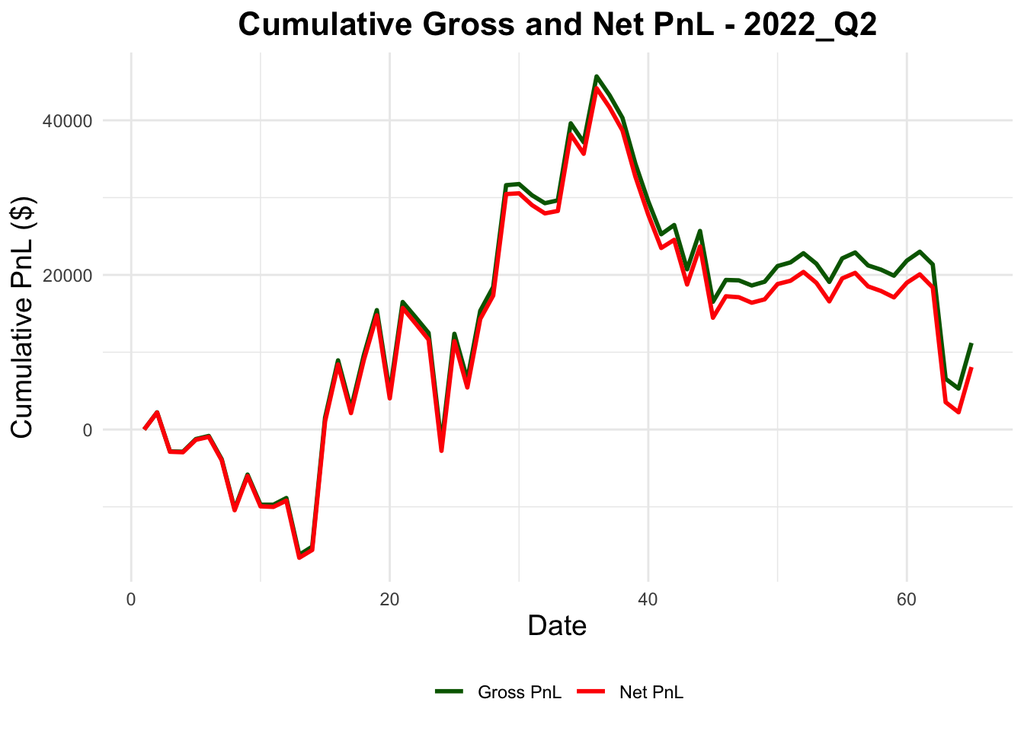

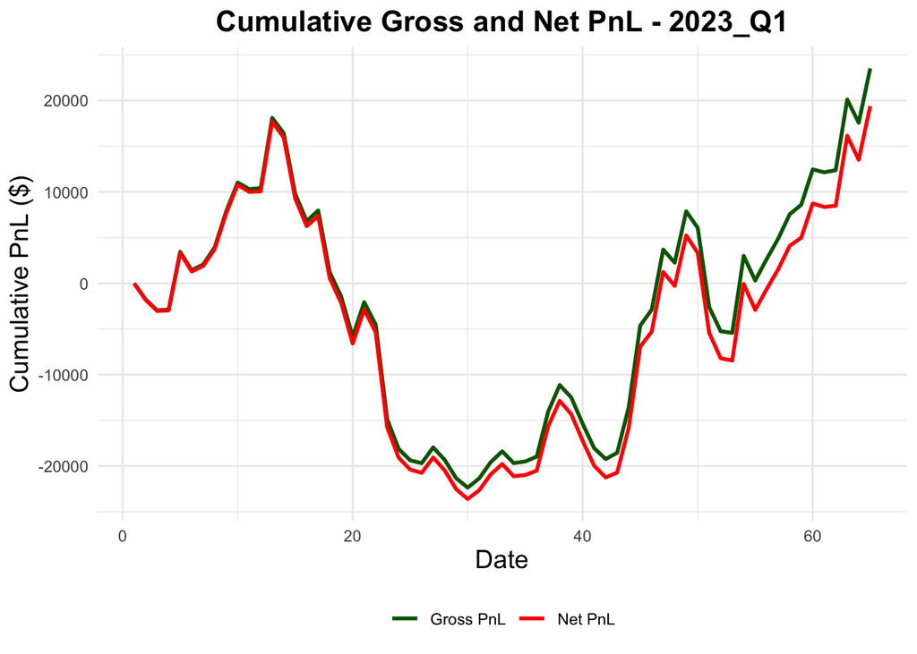

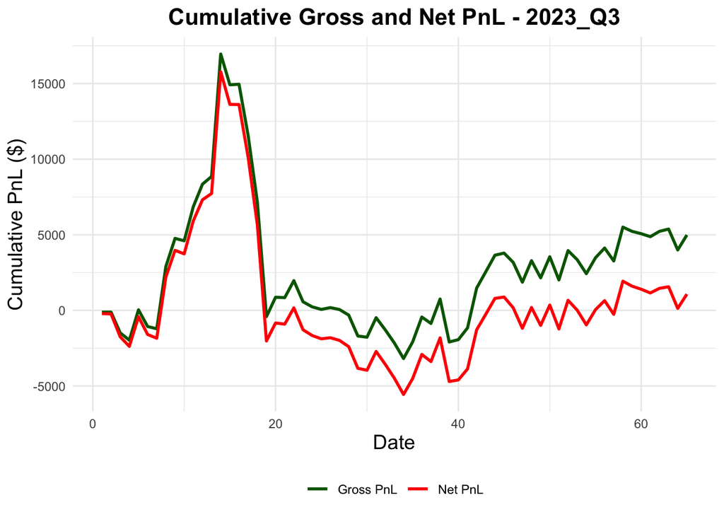

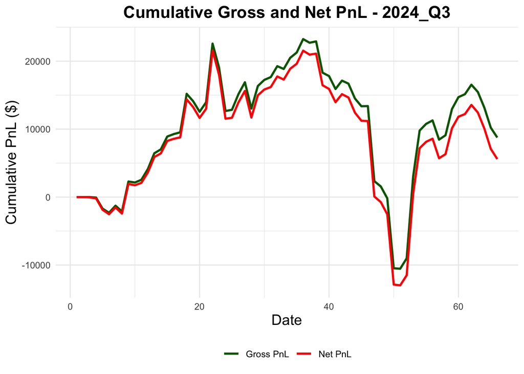

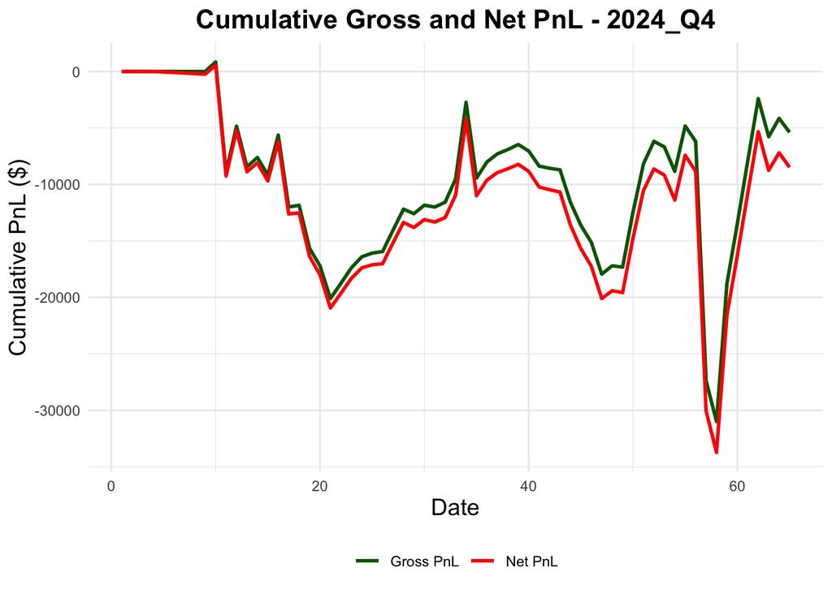

### Commentary on Cumulative PnL Plots

- **2022_Q2:**

### Conclusions and Future Improvements

1. **Overall Performance:**
   - The Volatility Breakout Momentum strategy yielded positive net Sharpe and Calmar ratios in most out-of-sample quarters, indicating robust risk-adjusted returns.
   - A significant drawdown occurred in 2024_Q4, highlighting the strategy’s potential vulnerability in certain market conditions.
2. **Strategy Robustness:**
   - **Consistent Trading Frequency:** The average daily number of trades remained stable across quarters, ensuring predictable trading behavior.
   - **Parameter Stability:** Holding fixed parameters from in-sample to out-of-sample periods maintained performance integrity in most cases.
3. **Areas for Enhancement:**
   - **Risk Management:** Incorporate stop-loss or trailing stop mechanisms to mitigate losses during adverse market conditions.
   - **Dynamic Parameter Adjustment:** Explore adaptive parameter settings based on real-time volatility or market regimes to enhance responsiveness.
   - **Additional Filters:** Implement trend filters or momentum indicators to reduce false signals and improve trade entry accuracy.
4. **Final Remarks:**
   - The Volatility Breakout Momentum strategy demonstrates strong performance in favorable market conditions but requires enhancements to handle market downturns effectively.